# ENSEMBLE LEARNING

Elliot Cohen, Ph.D.  
Galvanize Data Science & Machine Learning Instructor  
Denver, CO May 23 2018

# Pop Quiz!

## Instructions

1. Complete the following 6-question quiz without the help of your neighbor or the internet.
2. When 4 minutes are up, congregate with the 5 or 7 people sitting closest to you.
   - Compare your answers and identify the majority answer for each question.
   - For example, if 2 people answered "red" and 3 answered "blue", choose "blue".
3. Compile your team's majority-rules answers.
   - When all teams are done (no more than 2 minutes to discuss) the official solutions will be released.
   - Score your team's answers against the solutions.
   - Score your own answers against the solutions.
   - Who did better?
4. Come back together as one big group to discuss.

$$\frac{\mathrm d}{\mathrm d x} ( 3x^2 + 3 )$$

$$\frac{\mathrm d}{\mathrm d x} \left(\frac{2}{x^5}\right) $$

$$\frac{\mathrm d}{\mathrm d x} \left( x^2 e^x \right)$$

Who is the Prime Minister of Canada?

La Paz is the capital of what South American country?

*Taraxacum officinale*, the common dandelion, is a flowering herbaceous perennial plant of what family?

$$\frac{\mathrm d}{\mathrm d x} ( 3x^2 + 3 ) = 6x $$

$$\frac{\mathrm d}{\mathrm d x} \left(\frac{2}{x^5}\right) = \left(\frac{-10}{x^6}\right)$$

$$\frac{\mathrm d}{\mathrm d x} \left( x^2 e^x \right) = 2x e^x + e^x x^2$$

Who is the Prime Minister of Canada? Justin Trudeau

La Paz is the capital of what South American country? Bolivia

*Taraxacum officinale*, the common dandelion, is a flowering herbaceous perennial plant of what family? Asteraceae

## Imagine you are a high-flying Wall-Street Quant.

Suppose the probability of a homeowner defaulting on their mortgage is 0.05, 0.1, 0.25, and 0.55 for borrowers with excellent, good, fair and poor credit ratings, respectively. Traditionally, mortgages taken out by borrowers with excellent and good credit are very safe, and thus desirable for lenders. Mortgages by borrowers with fair and poor credit, however, have traditionally been deemed too risky, and thus are cheap to aquire (who wants to secure risky bets?). You propose purchasing and bundling together many risky mortgages and sell them effectively as a safe bet.

Conceptual Questions:

1. How in the world could this work?
2. What assumptions would you have to make? What happens if the assumptions are wrong?

Quantitative Questions:

1. How many mortages rated fair would you need to bundle together for the probability that the majority do not default is equivalent to that of a mortgage rated excellent?
2. How many rated poor would you need to bundle together?

# Your Answer Here

```python
%matplotlib inline

import numpy as np
import pandas as pd
import matplotlib.pyplot as plt
import scipy.stats as scs
```

```python
def probability_of_at_least_k_successes_in_n_independent_trials(n, p, k):
    '''Area under the binomial CDF given by (n, p) to the right of k'''
    return 1 - scs.distributions.binom(n, p).cdf(k - 1)

def probability_of_exactly_k_successes_in_n_independent_trials(n, p, k):
    '''Binomial PMF given by (n, p) evaluated at k'''
    return scs.distributions.binom(n, p).pmf(k)

def probability_of_majority_success_by_CDF(n, p):
    '''Probability of majority success in n independent trials.'''
    k = (n // 2) + 1
    return probability_of_at_least_k_successes_in_n_independent_trials(n, p, k)

def probability_of_majority_success_by_PMF(n, p):
    '''
    Given n independent voters (predictions)
    each with probability p of voting (predicting) correctly,
    return the probability that the majority vote (prediciton) is correct.
    '''
    k = (n // 2) + 1
    upper_tail = range(k, n + 1)
    probabilities = [probability_of_exactly_k_successes_in_n_independent_trials(n, p, k) for k in upper_tail]
    return sum(probabilities)
```

Given n independent voters (predictors) each with probability p of voting (predicting) correctly, the probability that the majority vote (prediciton) is correct is given by the binomial CDF:

$$ CDF_{Binom}(n, p) = \sum_{k=0}^{k} \binom{n}{k} p^{k} (1-p)^{n-k} $$

For example, with $n=5$, $p=0.7$, majority rules for $k$ in $[3,4,5]$. The probability of the majority voting correctly is given by:

$$ \binom{5}{3} 0.7^3 0.3^2 + \binom{5}{4} 0.7^4 0.3^1 + \binom{5}{5} 0.7^5 0.3^0 \approx 0.83 $$

```python
probability_of_majority_success_by_CDF(n=5, p=0.7)
```

```
0.8369199999999999
```

```python
probability_of_majority_success_by_CDF(n=55, p=0.7)
```

```
0.9990677001862475
```

```python
def grow_ensemble_until_desired_probability_achieved(p_individual, p_desired):
    n = 1
    p_ensemble = p_individual
    print('------------ start ------------')
    while p_ensemble < p_desired:
        p_ensemble = probability_of_majority_success_by_CDF(n, p_individual)
        if p_ensemble < p_individual:
            converged = False
            print('Warning: ensemble is worse than a single estimator with p < 0.5.')
            break
        else:
            n += 2 # odd number of voters makes the function increase monotonically
            print('Converging: ensemble probability = {:.4f} at n = {}'.format(p_ensemble, n))
            continue
    print('------------ end --------------')
```

```python
def plot_ensemble_probability(p_independent):
    ns = np.arange(1, 55, 2)
    ensemble_accuracies = [probability_of_majority_success_by_CDF(n, p_independent) for n in ns]
    fig, ax = plt.subplots(figsize=[16,5])
    ax.plot(ns, ensemble_accuracies, '.')
    ax.set_ylabel("Ensemble accuracy")
    ax.set_xlabel("Number of independent classifiers each with accuracy {p}".format(p=p_independent))
    ax.set_title("Accuracy of Ensemble of Independent Classifiers");
```

### Wisdom of the Crowd

```python
p_excellent, p_good, p_fair, p_poor = [1 - p for p in [0.05, 0.1, 0.25, 0.55]]
print('probability of success (no default) for debt rated excellent {}'.format(p_excellent))
print('probability of success (no default) for debt rated fair {}'.format(p_fair))
```

```
probability of success (no default) for debt rated excellent 0.95
probability of success (no default) for debt rated fair 0.75
```

```python
grow_ensemble_until_desired_probability_achieved(p_fair, p_excellent)
```

```
------------ start ------------
Converging: ensemble probability = 0.7500 at n = 3
Converging: ensemble probability = 0.8438 at n = 5
Converging: ensemble probability = 0.8965 at n = 7
Converging: ensemble probability = 0.9294 at n = 9
Converging: ensemble probability = 0.9511 at n = 11
------------ end --------------
```

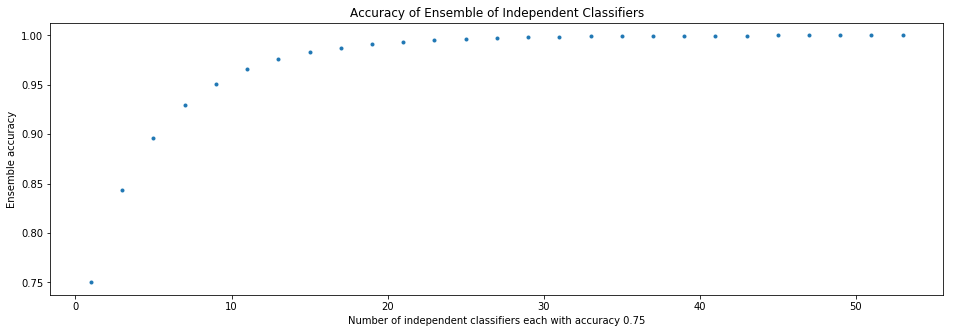

```python
plot_ensemble_probability(p_fair)
```

### Stupidity of the Crowd ?

```python
grow_ensemble_until_desired_probability_achieved(p_poor, p_excellent)
```

```
------------ start ------------
Converging: ensemble probability = 0.4500 at n = 3
Warning: ensemble is worse than a single estimator with p < 0.5.
------------ end --------------
```

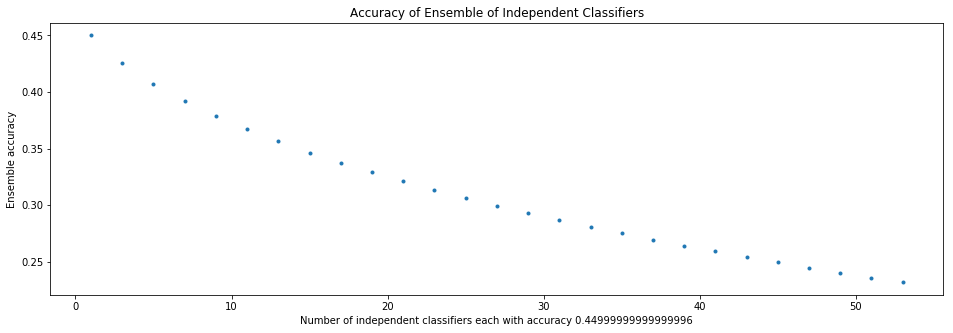

```python
plot_ensemble_probability(p_poor)
```

# Base Estimators for Ensemble Learning

## Decision Trees

Decision trees are a supervised, non-parametric learning method formulated as a series of sequential, binary splits on features with the goal of minimizing prediction error.

What distinguishes decision trees from other machine learning methods are the sequential splits on the features according to a "greedy algorithm", where the next split is decided by maximizing information gain (classification) or minimizing variance (regression).

**Classification trees** predict a discrete class (e.g. 0/1, stop/go, accept/reject, etc..) given a set of informative features. A leaf node outputs *the majority class of its elements*.

Information gain is estimated by Shannon Entropy, named after the father of Information Theory, Claude Shannon: $$ \text{Entropy} \ H(X) = -\sum\limits_{i=1}^n p(X_{i})\log p(X_{i}) $$

$$ \text{Information Gain} \ I(X,Y)= H(X)-H(X|Y) $$

**Regression trees** predict the value of a continuous target variable given a set of informative features. A leaf node outputs *the mean of its elements*.

We will use regression trees in the subsequent examples, but the same principles apply to both regression and classification.

To train a **regression tree**, we

- Iteratively divide the nodes such that *variance* of the parent node $P$ minus the weighted variance of the child nodes $C_L$ and $C_R$ is maximized

$$I_V = \text{var}(P) -\frac{|C_L|}{|P|}\text{var}(C_L) - \frac{|C_R|}{|P|}\text{var}(C_R) $$

$$I_V = \frac{1}{|P|}\left(\sum_{i \in P} (y_i - \bar{y_P})^2\right) - \left(\frac{|C_L|}{|P|}\frac{1}{|C_L|}\sum_{i \in C_L} (y_i - \bar{y_L})^2 + \frac{|C_R|}{|P|}\frac{1}{|C_R|}\sum_{i\in C_R} (y_i - \bar{y_R})^2\right)$$

$$I_V = \frac{1}{|P|}\left[\left(\sum_{i \in P} (y_i - \bar{y_P})^2\right) - \left(\sum_{i \in C_L} (y_i - \bar{y_L})^2 + \sum_{i\in C_R} (y_i - \bar{y_R})^2\right)\right]$$

- Stop when...
  - desired purity is achieved in the leaf nodes (homogeneity for classification, low variance of regression)
  - change in entropy for additional feature splits is small
  - maximum depth or minimum leaf size satisfied
- Prune trees by merging nodes

## Regression Trees: Simple Example

| $x_1$ | $x_2$ | $y$ |
| --- | --- | --- |
| 1 | 1 | 1 |
| 0 | 0 | 2 |
| 1 | 0 | 3 |
| 0 | 1 | 4 |

Prior to the split we guess the mean, 2.5, for everything, giving total squared error:

$$ E = (1-2.5)^2 + (2-2.5)^2 + (3-2.5)^2 + (4-2.5)^2 = 5$$ After we split on $x_1$ we guess 2 for rows 1 & 3 and 3 for rows 2 & 4:

$$ I = 5 - [(1-2)^2 + (3-2)^2 + (2-3)^2 + (4-3)^2] = 5 - 4 = 1 $$

## Regression Trees: Real Example

```python
from sklearn.model_selection import train_test_split
from sklearn.model_selection import cross_val_score
from sklearn.model_selection import TimeSeriesSplit
from sklearn import metrics
from sklearn import preprocessing
from sklearn import tree
from sklearn import ensemble

from IPython.display import Image
import pydotplus  # NOTE: May Require conda install graphviz
```

```python
# now let's try with a continuous target varialbe
yellow_taxi_url = 'https://raw.githubusercontent.com/Ecohen4/data-viz/project/project/weatherCabDataViz.csv'
taxi_data = pd.read_csv(yellow_taxi_url, parse_dates=['datetime'])
taxi_data.head()
```

|  | datetime | occupancy | rainSnowStatus | holWkend |
| --- | --- | --- | --- | --- |
| 0 | 2013-01-01 00:51:00 | 7209.2 | 0 | 1 |
| 1 | 2013-01-01 01:51:00 | 6575.8 | 0 | 1 |
| 2 | 2013-01-01 02:51:00 | 5434.4 | 0 | 1 |
| 3 | 2013-01-01 03:51:00 | 4038.0 | 0 | 1 |
| 4 | 2013-01-01 04:51:00 | 2415.9 | 0 | 1 |

```python
taxi_data['year'] = taxi_data.datetime.apply(lambda d: d.year)
taxi_data['month'] = taxi_data.datetime.apply(lambda d: d.month)
taxi_data['day'] = taxi_data.datetime.apply(lambda d: d.day)
taxi_data['hour'] = taxi_data.datetime.apply(lambda d: d.hour)
taxi_data['minute'] = taxi_data.datetime.apply(lambda d: d.minute)
taxi_data.set_index('datetime', inplace=True)
```

```python
taxi_data.sample(5)
```

| datetime | occupancy | rainSnowStatus | holWkend | year | month | day | hour | minute |
| --- | --- | --- | --- | --- | --- | --- | --- | --- |
| 2013-08-24 12:51:00 | 3952.3 | 0 | 1 | 2013 | 8 | 24 | 12 | 51 |
| 2013-10-13 10:51:00 | 4241.0 | 0 | 1 | 2013 | 10 | 13 | 10 | 51 |
| 2013-08-16 07:51:00 | 4479.2 | 0 | 0 | 2013 | 8 | 16 | 7 | 51 |
| 2013-07-27 15:51:00 | 4140.1 | 0 | 1 | 2013 | 7 | 27 | 15 | 51 |
| 2013-06-17 09:51:00 | 4932.7 | 0 | 0 | 2013 | 6 | 17 | 9 | 51 |

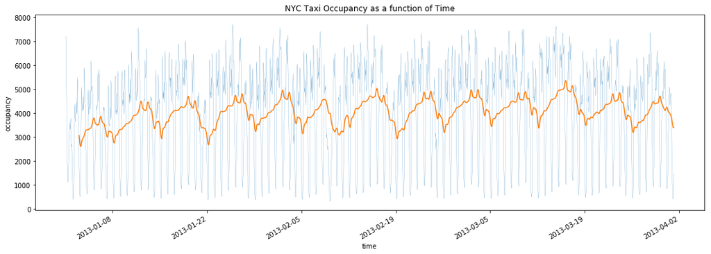

```python
# visualize a period of interest
start, end = taxi_data.index[0], taxi_data.index[24*90]
taxi_data = taxi_data.loc[start:end]
taxi_data.loc[start:end].occupancy.plot(figsize=(18,6), linewidth=0.2)
taxi_data.loc[start:end].occupancy.rolling(window=48).mean().plot(figsize=(18,6))
plt.xlabel('time')
plt.ylabel('occupancy')
plt.title('NYC Taxi Occupancy as a function of Time');
```

```python
# timeseries cross-validation
def time_series_cross_validation(target, features, classifier, model_name, n_splits=3):
    y = target
    scaler = preprocessing.StandardScaler().fit(features)
    X = scaler.transform(features)

    # time-series cross-validation
    tscv = TimeSeriesSplit(n_splits=n_splits)

    # Three subplots
    f, (ax1, ax2, ax3) = plt.subplots(3, sharex=False, sharey=False, figsize=(16,8))
    f.subplots_adjust(hspace=0.2)
    axes = [ax1, ax2, ax3]
    evaluation_metric = []
    split = 0
    for train_index, test_index in tscv.split(X):
        X_train, X_test = X[train_index], X[test_index]
        Y_train, Y_test = y[train_index], y[test_index]
        classifier.fit(X_train, Y_train)
        y_hat=classifier.predict(X_test)
        explained_variance = metrics.explained_variance_score(y_true=Y_test, y_pred=y_hat)
        evaluation_metric.append(explained_variance)
        axes[split].plot(pd.DataFrame({'y_hat': y_hat, 'y_true': Y_test}))
        split += 1
    axes[0].set_title('{}\n Mean Cross-Validated Explained Variance Score: {:.2f}'.format(
                    model_name, np.mean(evaluation_metric))
                     )
```

```python
target = taxi_data.pop('occupancy')
features = taxi_data
```

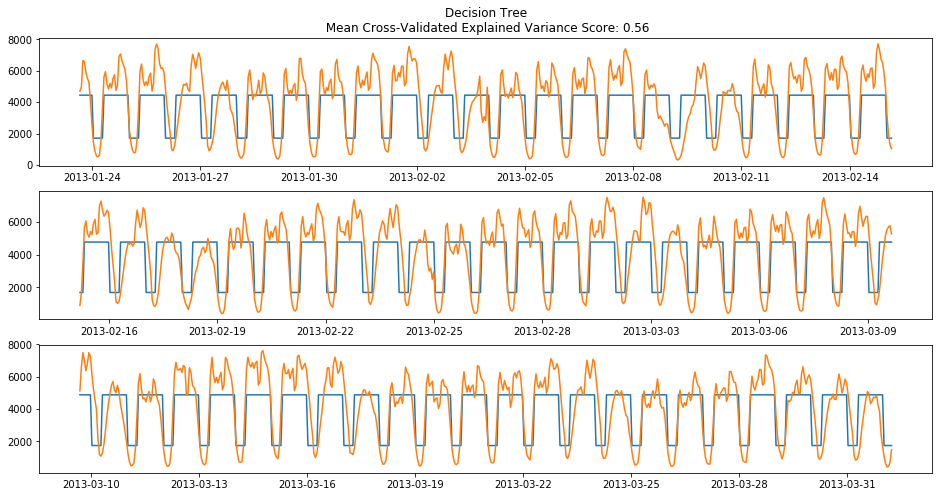

```python
time_series_cross_validation(
    target=target,
    features=features,
    classifier=tree.DecisionTreeRegressor(max_depth=1),
    model_name='Decision Tree'
)
```

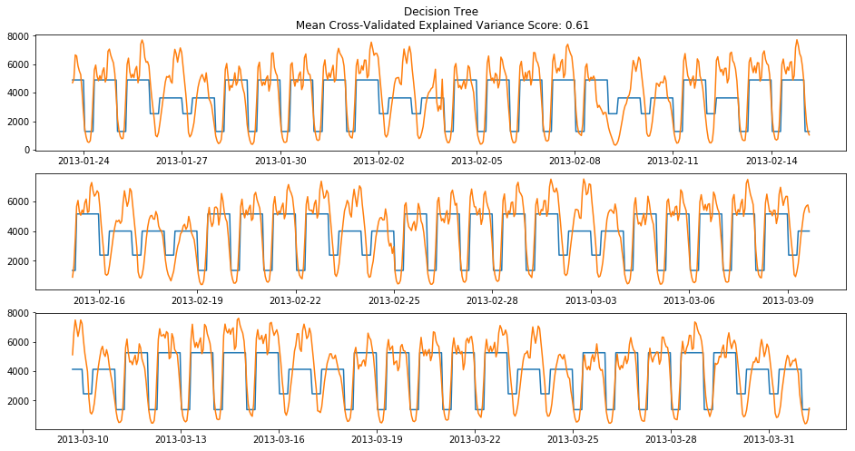

```python
time_series_cross_validation(
    target=target,
    features=features,
    classifier=tree.DecisionTreeRegressor(max_depth=2),
    model_name='Decision Tree'
)
```

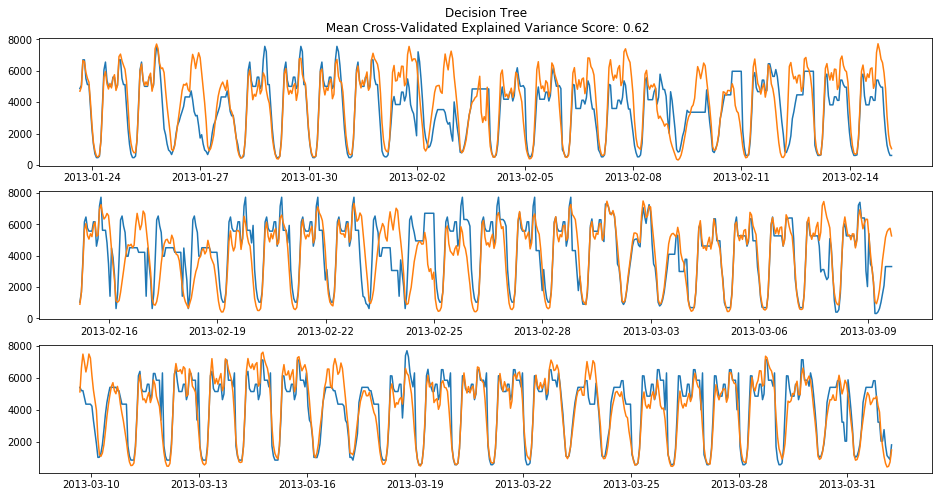

```python
time_series_cross_validation(
    target = target,
    features = features,
    classifier=tree.DecisionTreeRegressor(max_depth=10),
    model_name='Decision Tree'
)
```

This is great!  
We are able to expain 62% of the variance in taxi occupancy on *unseen* data with a single decision tree of depth 10.

But can we do even better?  
Enter Bagging, Boosting and Random Forests.

# Ensemble of Decision Trees

Decision trees, left unchecked, tend to overfit to your training data. That is, they fit to both the signal and the noise. In general, overfitting leads to poor generalizability. This is often discussed in terms of the **bias - variance** tradeoff. Bias is the distance between observed and predicted values, while variance is the spread of predictions given a set of features.

For example, if you ask me to guess people's age, and I guess 35 every time, this is an extreme case of a high bias, low variance model (variance is actually 0). By comparison, if you ask me to guess people's age and I am almost always within +-5 years, but my prediciton for the same person (or similar persons) bounces over/under, this is a low (medium?) bias, high variance model.

We can leverage the bias-variance tradeoff to our advantage by creating a large number of predictors (decision trees), each with low-bias (a fully-grown tree) but high variance (likely overfit), and average their individual predictions (regression) or take a majority-vote (classification) to *decrease variance* while maintaining low-bias.

But wait.... if I fit 1000 decision trees on the same training data, will they all be the same?  
**Yes**! Decision trees are deterministic.

So what can we do?

## Bagging

**Boostrap**!  
Randomly sample (with replacement) from the training data to create many (let's say 1000) synthetic training sets, and fit a tree to each of those. Now each tree will be slightly different on account of slightly different data. This procedure gives us **bootstrap aggregating**, also known as **bagging**.

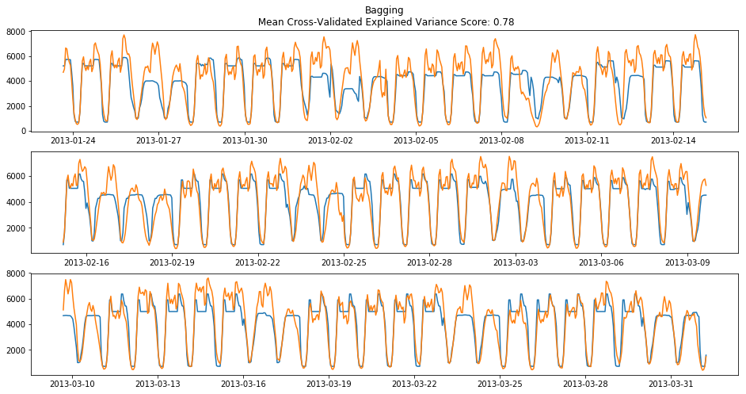

```python
n_features = features.shape[1]

time_series_cross_validation(
    target=target,
    features=features,
    classifier=ensemble.RandomForestRegressor(criterion='mse',  # feature-splitting criterion
                                              n_estimators=500, # number of trees
                                              max_depth=5,      # max tree depth
                                              max_features=n_features
                                             ),
    model_name='Bagging'
)
```

**Bagging** is a huge improvement over a single decision tree. But is there is still one problem.

Boostrapped trees are highly correlated. The ensemble variance decreases inversely proportional to the covariance between trees. That is, ff we could (magically) create completely uncorrelated trees (e.g. independent) then we can reduce the variance of our ensemble monotoincally as a function of the number of trees (m). Unfortunately this is not possible, but we can get darn close...

## Random Forest

Random Forests build on bagging by randomly selecting a subset of features at each split.

For example, if you have k=100 features, and you set the max number of features to the square-root of k, then at each split, you only have the option of evaluating 10 different feature splits. At each subsequent node, all of the features are back in the pool, and you again randomly select 10. We still follow the *greedy algorithim* of maximizing information gain, but have added stochasticity to the model fitting process. It is no longer deterministic.

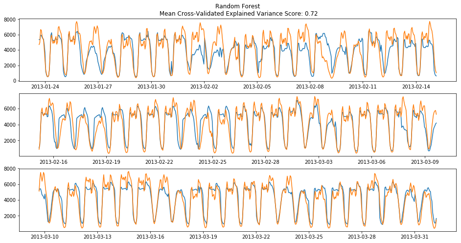

```python
time_series_cross_validation(
    target=target,
    features=features,
    classifier=ensemble.RandomForestRegressor(criterion='mse',  # feature-splitting criterion
                                              n_estimators=500, # number of trees
                                              max_depth=10,     # max tree depth
                                              max_features='sqrt'
                                             ),
    model_name='Random Forest'
)
```

## Boosting

Both bagging and random forests attempt to take many low-bias, high-variance fully-grown decision trees, and aggregate them together to reduce prediction variance while maintaing low prediction bias.

What if we flip our strategy on its head?

What if we started with a high-bias, low-variance decision stump (a decision tree with just a couple splits), and arrange many in series, passing the residuals of the first model as the target of the next, iteratively to chip away at the bias while maintianing low-variance. That is **boosting**.

If you're an engineer, you can think of bagging/random forest as a parallel process, whereas boosting is sequential.

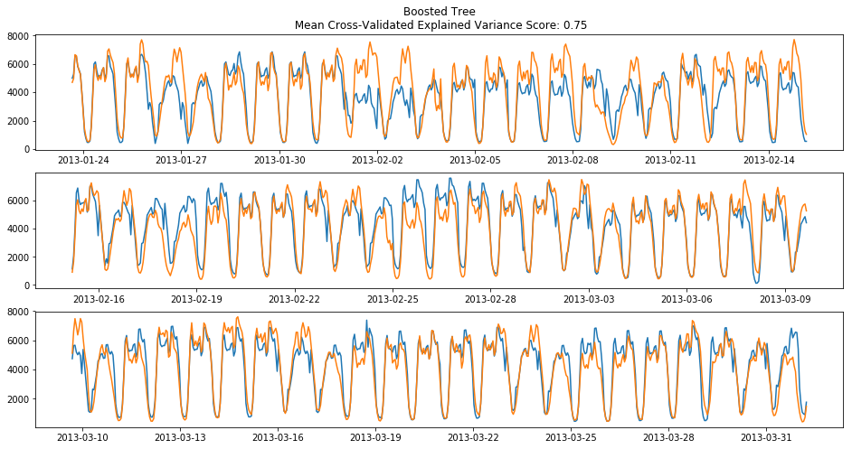

```python
time_series_cross_validation(
    target=target,
    features=features,
    classifier=ensemble.GradientBoostingRegressor(criterion='mse', # feature splitting criterion
                                                  loss='lad',      # overall loss function to be minimized
                                                  n_estimators=500 # number of trees
                                                 ),
    model_name='Boosted Tree'
)
```